# Colinearidade

Dr. Wilson Frantine-Silva

# Introdução

Neste exercício veremos como tratar a colinearidade entre preditores de um modelo. Lembrando que nos modelos de nicho ecológico, os preditores são geralmente as variáveis bioclimáticas, altitude, biomas, solo, radiação solar, entre outras…

## Preparando o ambiente

Neste exercício usaremos os pacotes abaixo. Caso não tenha algum deles basta utilizar o comando: `install.packages("nome_do_pacote")`

```r
library("ggplot2")
library("raster")
library("maptools")
library("dismo")
library("corrplot")
```

### Setando o diretório

Crie o hábito de setar diretórios onde irá trabalhar. Tudo fica mais fácil de ser encontrado depois.

```r
setwd("/media/wilson/MIDGARD/Documents/Academico/AARE - MNE/Aula 9 - Colinearidade/")
```

### Carregando dados ambientais:

Vamos utilizar os dados ambientais do pacote `dismo` como referência, assim copiaremos desse raster a extenção, resolução e projeção.

```r
#primeiro setamos uma varíavel para captura o caminho dos arquivos no pacote dismo
path <- file.path(system.file(package="dismo"), 'ex')
#depois criamos uma lista neste diretório que tem o padrão grd no final (por isso o sinal de $)
files <- list.files(path, pattern='grd$', full.names=TRUE )
#agora criamos o objeto raster do tipo stack
predictors <- stack(files)
```

Isso deve resultar em um stack de 9 variáveis, com os seguintes nomes: `bio1, bio12, bio16, bio17, bio5, bio6, bio7, bio8, biome`

### Alguns dados de ocorrência para extrairmos os dados

```r
#mais uma vez utilizamos os dados do pacote dismo
file <- paste(system.file(package="dismo"), "/ex/bradypus.csv", sep="")
#agora criamos uma tabela com os dados da preguiça (Bradypus variegatus)
bradypus <- read.table(file,  header=TRUE,  sep=',')
#Veja a tabela abaixo
head(bradypus)
```

```
##               species      lon      lat
## 1 Bradypus variegatus -65.4000 -10.3833
## 2 Bradypus variegatus -65.3833 -10.3833
## 3 Bradypus variegatus -65.1333 -16.8000
## 4 Bradypus variegatus -63.6667 -17.4500
## 5 Bradypus variegatus -63.8500 -17.4000
## 6 Bradypus variegatus -64.4167 -16.0000
```

Neste caso, não precisaremos da coluna 1, com o nome da espécie então executaremos o seguinte código:

```r
bradypus  <- bradypus[,-1]
```

Vamos olhar em um plot simples como os dados ficam sobre o mapa. Plotando os dados

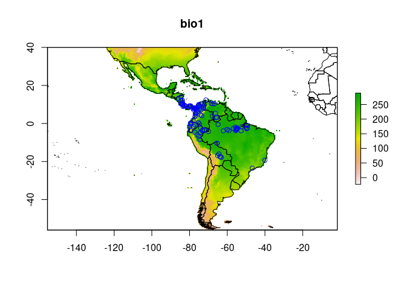

```r
#carregando vetor com os limites dos continentes
data(wrld_simpl)
#Plotando a primeira variavel para termos um fundo (Opcional)
plot(predictors, 1)
#Plotando os limites
plot(wrld_simpl, add=TRUE)
#Plotando os pontos
points(bradypus, col='blue')
```

Agora que temos esses dados, vamos extrair os valores de cada ponto

#extraindo os dados ambientais

```r
#Criamos uma variável chamada prevals para abrigar os dados extraídos dos pontos de presença
presvals <- extract(predictors, bradypus)
#Setamos uma valor fixo para a raíz aleatória do R
set.seed(1)
#criamos um vetor de pontos aleatórios sobre a área das variáveis preditoras
backgr <- randomPoints(predictors, 500)
#extraímos os valores a partir desses pontos
absvals <- extract(predictors, backgr)
#criamos um vetor de 1 ou 0, para dizer se um determinado ponto é de presença ou ausência
pb <- c(rep(1, nrow(presvals)), rep(0, nrow(absvals)))
#Agora criamos um dataframe final, combinando os valores dos dados de ocorrência
sdmdata <- data.frame(cbind(pb, rbind(presvals, absvals)))
#Apenas transformamos a coluna bioma em fator
sdmdata[,'biome'] = as.factor(sdmdata[,'biome'])
#Veja o resultado abaixo
head(sdmdata)
```

```
##   pb bio1 bio12 bio16 bio17 bio5 bio6 bio7 bio8 biome
## 1  1  263  1639   724    62  338  191  147  261     1
## 2  1  263  1639   724    62  338  191  147  261     1
## 3  1  253  3624  1547   373  329  150  179  271     1
## 4  1  243  1693   775   186  318  150  168  264     1
## 5  1  243  1693   775   186  318  150  168  264     1
## 6  1  252  2501  1081   280  326  154  172  270     1
```

### Olhando a colinearidade

Vamos observar agora a colinearidade desses preditores na área que vamos estudar.  
Note que os valores que observaremos dizem respeito tanto aos dados de presença quanto aos dados de background, ou seja mostra de forma geral a colinearidade entre os preditores que pretendemos utilizar no modelo.  
Para visualizar a relação é bastante simples. Basta plotar os dados com a função `pairs` do pacote `graphics`, nativo do R.

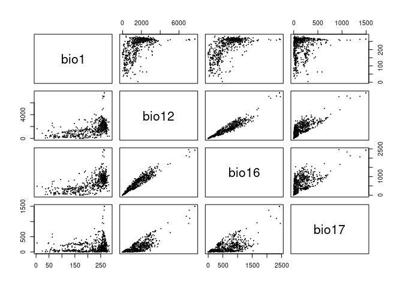

```r
graphics::pairs(sdmdata[,2:5], cex=0.1)
```

As variáveis que exibem colinearidade são aquelas que apresentam dispersão próximas da linearidade. Ou seja, uma aumenta ou diminui em função da outra. No nosso exemplo, `bio12` e `bio16`, são bons exemplos.

Vejamos essa relação mais de perto.

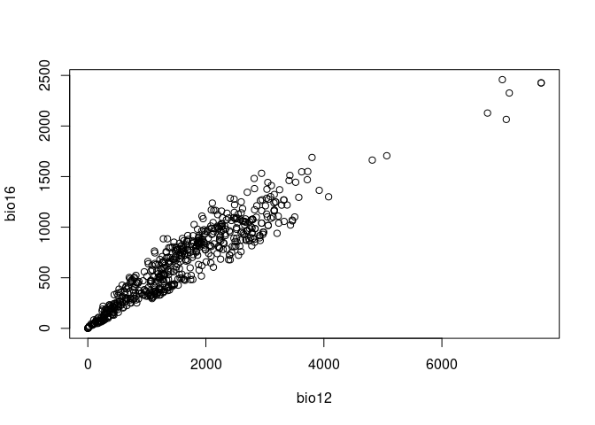

```r
plot(sdmdata[,c(3,4)])
```

Note que no caso de `bio12` vs `bio16` é muito fácil observar a relação entre esses preditores. Contudo, o que dizer da relação entre `bio16` vs `bio17`. Seriam esses correlacionados? qual o limíte aceitável?

Tudo fica mais fácil se quantificarmos a diferença. Índices de correlação de Person podem nos dar uma quantificação da relação entre os preditores. Para isso, faremos o seguinte:

##Medindo a colinearidade

Por conveniência, vamos utilizar um pacote chamado `corrplot`, que apresenta uma função otimizada para o nosso propósito. Você pode instalar esse pacote, correndo o código comentado.

```r
#if(!require(corrplot)){
#    install.packages("corrplot")
#}
library("corrplot")
```

Uma vez carregado o pacote, vamos à função:

```r
# Para criar a matrix de correlação basta utilizar a função
cors <- cor(presvals)
# checking the table
cors
```

```
##              bio1       bio12       bio16       bio17        bio5        bio6
## bio1   1.00000000  0.05364955  0.06743062  0.04331060  0.94250240  0.91386031
## bio12  0.05364955  1.00000000  0.92643374  0.86053523 -0.08991102  0.18148337
## bio16  0.06743062  0.92643374  1.00000000  0.66297006 -0.04081337  0.17998963
## bio17  0.04331060  0.86053523  0.66297006  1.00000000 -0.08168529  0.11384821
## bio5   0.94250240 -0.08991102 -0.04081337 -0.08168529  1.00000000  0.74778656
## bio6   0.91386031  0.18148337  0.17998963  0.11384821  0.74778656  1.00000000
## bio7  -0.17453449 -0.38418535 -0.32087945 -0.27297842  0.14512737 -0.54821686
## bio8   0.96584412  0.01921980  0.04562234  0.04203550  0.94225305  0.81035244
## biome  0.04027417 -0.25170955 -0.22475186 -0.19086026  0.06770097 -0.02505668
##              bio7        bio8       biome
## bio1  -0.17453449  0.96584412  0.04027417
## bio12 -0.38418535  0.01921980 -0.25170955
## bio16 -0.32087945  0.04562234 -0.22475186
## bio17 -0.27297842  0.04203550 -0.19086026
## bio5   0.14512737  0.94225305  0.06770097
## bio6  -0.54821686  0.81035244 -0.02505668
## bio7   1.00000000 -0.02055398  0.12329956
## bio8  -0.02055398  1.00000000  0.06424123
## biome  0.12329956  0.06424123  1.00000000
```

Veja que a matrix é espelhada, ou seja a diagonal superior é a mesma da inferior, bem como a diagonal sempre terá o valor de 1, já que compara a variável com ela mesma.

Caso queira salvar a matrix de correlação use a linha abaixo:

```r
#write.csv(cors, "nomedoseuarquivo.csv", quote = F, sep="\t", row.names = F, col.names = T)
```